# Opgave 7 løsninger

## 7.12,

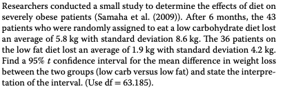

```r
n_1 = 43
x_1 = 5.8
s_1 = 8.8
n_2 = 36
x_2 = 1.9
s_2 = 4.2

conf_func <- function(n1, x1, s1, n2, x2, s2, z) {
  z_scor <- qnorm(1- z / 2)
  lower <- (x1 - x2 - z_scor * (sqrt((s1^2/n1)+(s2^2/n2))))
  above <- (x1 - x2 + z_scor * (sqrt((s1^2/n1)+(s2^2/n2))))
  paste(lower, above)
}

conf_func(n1 = n_1, x1 = x_1, s1 = s_1, n2 = n_2, x2 = x_2, s2 = s_2, z = 0.05)
```

```
## [1] "0.933433946554484 6.86656605344552"
```

vi kan med 95% sikkerhed sige at forskellen i mellem de to populations mean ligger i intervallet.

## 7.14

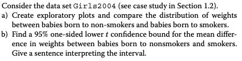

### a)

```r
girls <- read.csv("../MatStat-R/data/Girls2004.csv")

head(girls)
```

|  | ID | State | MothersAge | Smoker | Weight | Gestation |
| --- | --- | --- | --- | --- | --- | --- |
| 1 | 1 | WY | 15-19 | No | 3085 | 40 |
| 2 | 2 | WY | 35-39 | No | 3515 | 39 |
| 3 | 3 | WY | 25-29 | No | 3775 | 40 |
| 4 | 4 | WY | 20-24 | No | 3265 | 39 |
| 5 | 5 | WY | 25-29 | No | 2970 | 40 |
| 6 | 6 | WY | 20-24 | No | 2850 | 38 |

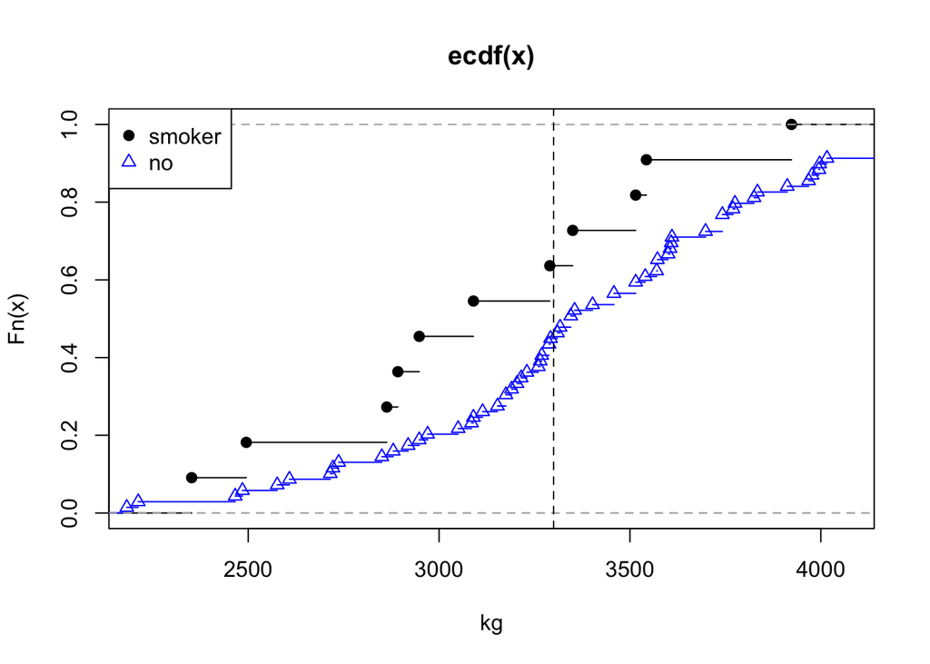

```r
girls_smoker <- subset(girls,select = Weight, subset = Smoker == "Yes",drop = TRUE)
girls_no     <- subset(girls,select = Weight, subset = Smoker == "No" ,drop = TRUE)

plot.ecdf(girls_smoker, xlab = "kg")
plot.ecdf(girls_no, col = "blue", pch = 2, add = TRUE)
abline(v = 3300, lty = 2)
legend("topleft", legend = c("smoker", "no"),
    col = c("black", "blue"), pch = c(19, 2))
```

### b)

```r
t.test(girls_no, girls_smoker, alternative = "greater", conf.level = 0.95)
```

```
##
##  Welch Two Sample t-test
##
## data:  girls_no and girls_smoker
## t = 1.8552, df = 14.35, p-value = 0.04211
## alternative hypothesis: true difference in means is greater than 0
## 95 percent confidence interval:
##  14.99055      Inf
## sample estimates:
## mean of x mean of y
##  3401.580  3114.636
```

vi er sikek rpå at mean vægt er mellem de to konfidensbånd.

## 7.24

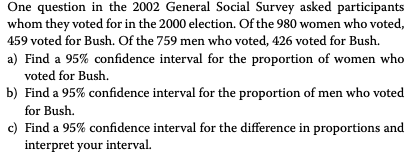

### a)

```r
prop.test(459, 980, correct = TRUE)
```

```
##
##  1-sample proportions test with continuity correction
##
## data:  459 out of 980, null probability 0.5
## X-squared = 3.7969, df = 1, p-value = 0.05135
## alternative hypothesis: true p is not equal to 0.5
## 95 percent confidence interval:
##  0.4368038 0.5001819
## sample estimates:
##         p
## 0.4683673
```

### b)

```r
prop.test(426, 759, correct = TRUE)
```

```
##
##  1-sample proportions test with continuity correction
##
## data:  426 out of 759, null probability 0.5
## X-squared = 11.152, df = 1, p-value = 0.0008396
## alternative hypothesis: true p is not equal to 0.5
## 95 percent confidence interval:
##  0.5250797 0.5968214
## sample estimates:
##         p
## 0.5612648
```

## 7.39

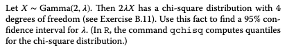

```r
qchisq(p = c(0.025, 0.975),
       df = 4)
```

```
## [1]  0.4844186 11.1432868
```

## 7.A

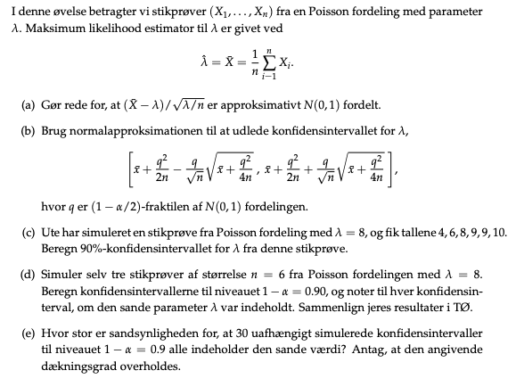

### a)

vi har følgende

$$E(X_i) = \lambda \\var(X_i)=\lambda$$

Det giver os at

$$\frac{(\bar X - \mu)}{\sqrt(\sigma / n)} = \frac{(X-\lambda)}{\sqrt{\lambda/n}}$$

vi har stikpvøe fra possion. Vi ved middelværdi go varians. Fra clt ved vi at de er standardnormalt fordel

### c)

```r
sample <-  c(4,6,8,9,9,10)
q <- qnorm(0.95)
low <- mean(sample) + q^2/6 - qnorm(0.95)/6*(sqrt(mean(sample) + q^2/4*6))
high <- mean(sample) + q^2/6 + qnorm(0.95)/6*(sqrt(mean(sample) + q^2/4*6))

c(low,high)
```

```
## [1] 7.178879 9.056302
```

udregning for konfidens interval. Fra ugeseddel står formlen.

8 er vores parameter er indenfor.

### d) simulering

```r
n = 100
result = numeric(n)
q <- qnorm(0.95)
for (i in 1:n) {
  samlpe1 <- rpois(n = 6, 8) # simuler 100 gange
  low <-  mean(samlpe1) + q^2/6 - q/6*(sqrt(mean(samlpe1) + q^2/24))
  high <- mean(samlpe1) + q^2/6 + q/6*(sqrt(mean(samlpe1) + q^2/24))
  result[i] <- floor((low <= 8) * 0.5 + 0.5 * (8 <= high)) # checke rom den ligger indenfor
}

mean(result)
```

```
## [1] 0.4
```

### e)

ved hver simulation bør vi have 90% dermed er sand

```r
0.9^30
```

```
## [1] 0.04239116
```

ca 4%

## 7.40

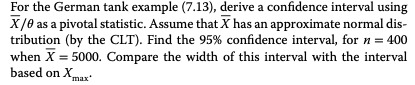

> pivotal statistic: er en funktion af observationer og uboseverede parameter så sandsynligheds fordelingen ikke afhænger af den ukendte parameter.

vi har uniform fordeling med nogle grænser. vi skal se på konfidens intetval

laver beregning se video igen

```r
q <- qnorm(0.95)
low <-  5000 / (1/2+q/sqrt(12*400))
high <- 5000 / (1/2- q/sqrt(12*400))
c(low,high)
```

```
## [1]  9546.696 10498.498
```

intervallet for Xmax er en del mere snævert. det kan dog skyldes at for store stikprøver vil X max jo næsten være theta.

## 7.22

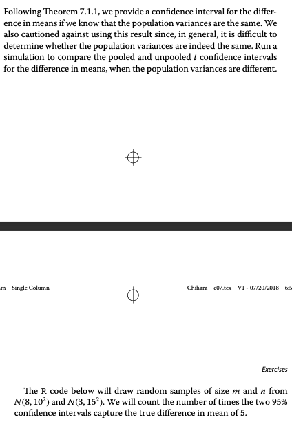

har givet følgende kode

```r
pooled.count <- 0
unpooled.count <- 0
m <- 20
n <- 10

N <- 100000
for (i in 1:N){
  x <- rnorm(m, 8, 10)
  y <- rnorm(n, 3, 15)

  CI.pooled <- t.test(x,y, var.equal = TRUE)$conf
  CI.unpooled <- t.test(x,y)$conf

  if (CI.pooled[1] <= 5 && 5 <= CI.pooled[2])
    pooled.count <- pooled.count + 1

  if (CI.unpooled[1] <= 5 && 5 <= CI.unpooled[2])
    unpooled.count <- unpooled.count + 1
}

pooled.count/N
```

```
## [1] 0.91409
```

```r
unpooled.count/N
```

```
## [1] 0.9496
```

### a)

konfidens for pooled er lavere.

### b)

kører igen

### d)

jo tætter sample sizee er på hinaden er de lig hinanden.

## 8.15, professor

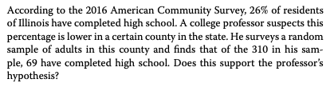

```r
# profesro har observeret
value <- 69 / 310
value
```

```
## [1] 0.2225806
```

sandsynligheden at observere 69 eller færre:

```r
pbinom(69, 310, 0.26) # tosidet
```

```
## [1] 0.0736073
```

binomial fordeling da det er enten eller.

dbinom er pdf vi skal brug pbinom. accepter h0.

## 8.11, t-test, permutation test,

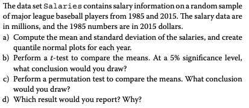

```r
Salaries <- read.csv("../MatStat-R/data/Salaries.csv")
head(Salaries)
```

|  | League | Salary | Year |
| --- | --- | --- | --- |
| 1 | National | 0.5577500 | 1985 |
| 2 | National | 0.5187075 | 1985 |
| 3 | National | 2.1000000 | 2015 |
| 4 | American | 8.0000000 | 2015 |
| 5 | National | 0.5689050 | 1985 |
| 6 | American | 0.5081000 | 2015 |

### a)

mean og sd

```r
mean(Salaries$Salary)
```

```
## [1] 1.402563
```

```r
sd  (Salaries$Salary)
```

```
## [1] 1.724511
```

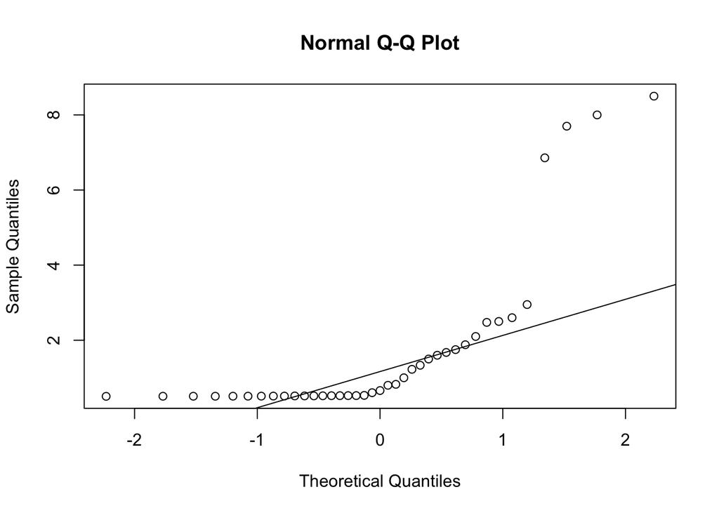

```r
year_1985 <- subset(Salaries$Salary, Salaries$Year == '1985')
year_2015 <- subset(Salaries$Salary, Salaries$Year == '2015')

qqnorm(year_2015)
qqline(year_2015)
```

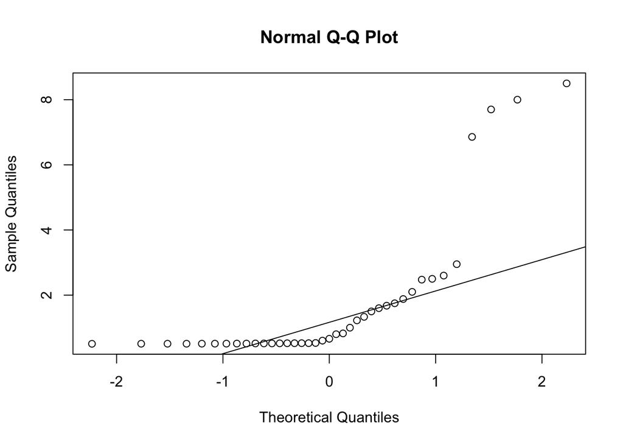

```r
qqnorm(year_2015)
qqline(year_2015)
```

### b) t means

```r
t.test(year_2015, year_1985)
```

```
##
##  Welch Two Sample t-test
##
## data:  year_2015 and year_1985
## t = 2.0528, df = 46.346, p-value = 0.04576
## alternative hypothesis: true difference in means is not equal to 0
## 95 percent confidence interval:
##  0.01493396 1.50433265
## sample estimates:
## mean of x mean of y
## 1.7389722 0.9793389
```

laver t test. De to fordelinger virker ikke til at komme fra den samme foreling. Så der er lav sandsynlighed for de kommer fra samme fordeling. Lønninger har ændret sig meget.

### c) permutation test

```r
observed <-  mean(year_1985) - mean(year_2015)
observed
```

```
## [1] -0.7596333
```

```r
N <-  10^5 - 1
N
```

```
## [1] 99999
```

```r
result <- numeric(N)
for(i in 1:N) {
  meantime <- tapply(sample(Salaries$Salary, replace = FALSE),
                     Salaries$Year, mean)
  result[i] <- meantime['1985'] - meantime['2015']
}

p_lille <- (sum(result <= observed) + 1) / (N + 1)
p_stor <- (sum(result >= observed) + 1) / (N + 1)
p_værdi <- 2*min(p_lille, p_stor)

print(p_værdi)
```

```
## [1] 0.06438
```

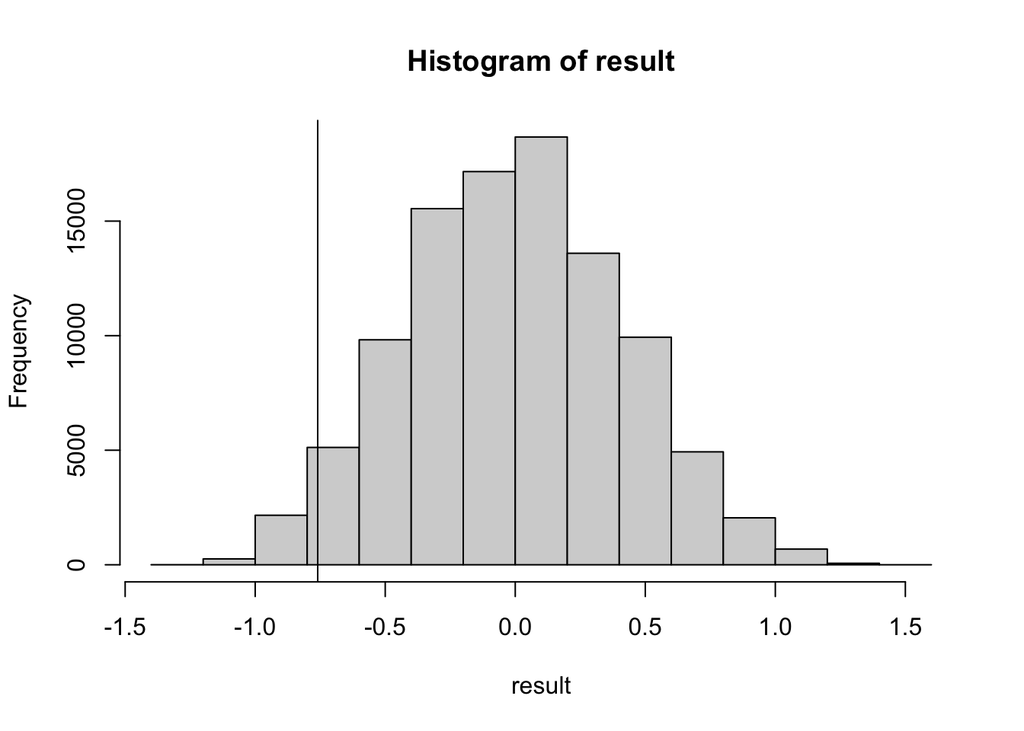

```r
hist(result)
abline(v = observed)
```

mere se på en ensidet test.

## 7.14, den har du lavet

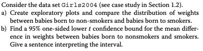

## 7.29, confidence, bootstrp confidence intervals.

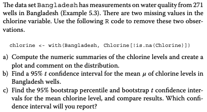

### a)

```r
Bangladesh <- read.csv("../MatStat-R/data/Bangladesh.csv")
cholorine <- with(Bangladesh, Chlorine[!is.na(Chlorine)])
```

```r
summary(cholorine)
```

```
##    Min. 1st Qu.  Median    Mean 3rd Qu.    Max.
##    1.00    5.00   14.20   78.08   55.50 1550.00
```

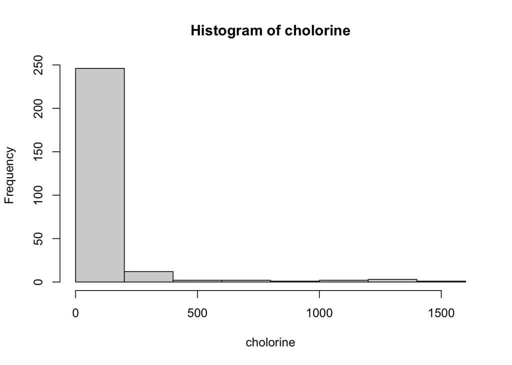

```r
hist(cholorine)
```

skæv fordeling

### b)

```r
t.test(cholorine)
```

```
##
##  One Sample t-test
##
## data:  cholorine
## t = 6.0979, df = 268, p-value = 3.736e-09
## alternative hypothesis: true mean is not equal to 0
## 95 percent confidence interval:
##   52.87263 103.29539
## sample estimates:
## mean of x
##  78.08401
```

### c) bootstrap t test

```r
xbar <- mean(cholorine)
N <- 10^4
n <- length(cholorine)
Tstar <- numeric(N)
for (i in 1:N){
  x <- sample(cholorine, size = n, replace = TRUE)
  Tstar[i] <- (mean(x) - xbar) / (sd(x)/sqrt(n))
}

quantile(Tstar, c(0.025, 0.975))
```

```
##      2.5%     97.5%
## -2.586257  1.691423
```

```r
xbar - quantile(Tstar, c(0.975, 0.025))  * sd(cholorine) / sqrt(n)
```

```
##     97.5%      2.5%
##  56.42519 111.20129
```

koden fra bogen og ændret til clorine.

vi kan se at værdier er skubbet og blevet større i bootstrap.

### d)

bootstrap er smart da den laver korrektur på en skæv fordeling.

## 7.43, cereal problem,

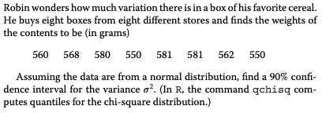

hun måler morgen mads produkter. opgaven er vi skal findes konfidens interval

lige over fik op formlen

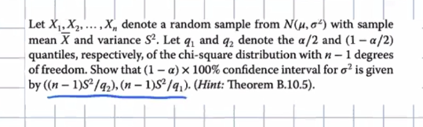

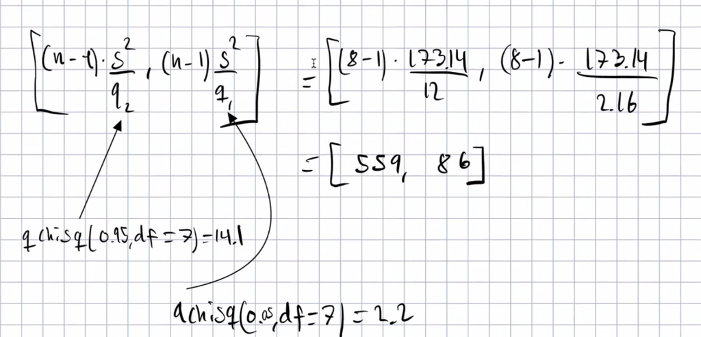

bredt interval men som man får med lille data.

## 8.6, model poisson

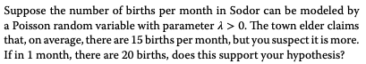

Beregnes af test statistik.

```r
z_possion <- function(TS, lambda){
  z <- (TS - lambda) / sqrt(lambda)
  z
}

z_possion(20, 15)
```

```
## [1] 1.290994
```

```r
# z niveau 0.95
qnorm(1-0.05/2)
```

```
## [1] 1.959964
```

```r
library(glue)
glue("Vi har altså {z_possion(20, 15)} < {qnorm(1-0.05/2)}")
```

```
## Vi har altså 1.29099444873581 < 1.95996398454005
```

Vi acceptere H0, og der er altså i gennemsnitlig 15 fødsler om måneden.